# Etude du sondage réalisé par les étudiants de Tours

YILMAZ Ilayda et QUARTIER Laurine

18/12/23

### Présentation du sujet

A l’aide d’un sondage réalisé via *Célène* sur des étudiants de Licence d’Economie et de Gestion de l’[université de Tours](https://www.univ-tours.fr/), nous nous sommes posées la question suivante :

**Quel est l’impact du nombre de soirées réalisées par semaine sur le temps de travail des répondants selon leur année d’étude ? Cette variation diffère-t-elle selon le genre de l’individu ?**

En observant les données de ce sondage, nous avons tenté de répondre à cette question. Ce sondage compte **208** répondants dont **168** soit **80.8%** en filière Economie. Les représentations ci-dessous permettent de présenter la répartition des étudiants selon deux variables :

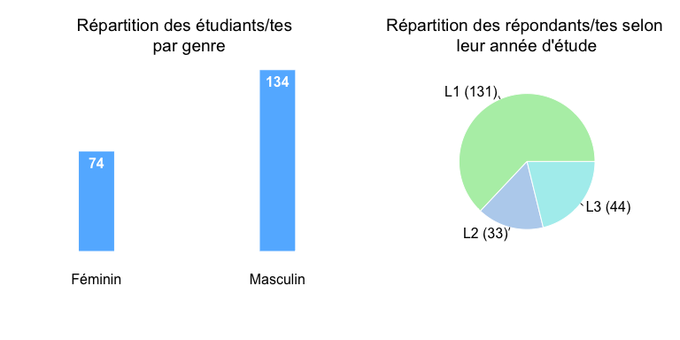

Avec ces graphiques on peut noter qu’il y a **64%** de garçons dans les répondants du sondage. On remarque également que les L1 représentent **63%** des étudiants ayant répondu au sondage contre seulement **16%** de L2 et **21%** de L3.

### 1. Nombre de soirées par semaine - Temps de travail

Dans un premier temps, nous allons étudier la répartition du nombre de soirées par semaine en moyenne des étudiants et leur temps de travail personnel scolaire séparément.

Nous avons modifié la variable Nombre de soirées par semaine en moyenne, de telle sorte que les modalités 0.25 et 0.5 soient comptabilisées dans la modalité 0, et que la modalité 4 soit comptabilisée dans la modalité 3. En effet, pour la suite de notre étude et la réalisation de nos différents graphiques et tableaux, nous trouvions plus simple le fait de travailler avec seulement des modalités entières.

De plus, très peu d’étudiants avaient répondu faire 4 soirées par semaine donc il nous semblait plus judicieux d’intégrer directement cette valeur à la modalité 3 soirées par semaine en moyenne.

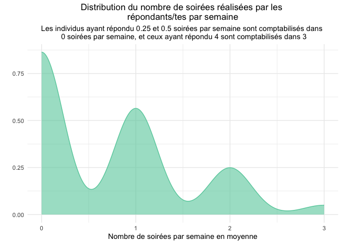

Nous avons choisi de supprimer les valeurs 160 et 170 de la variable temps de travail personnel scolaire par semaine, car ces valeurs nous paraissaient incohérentes. En effet une journée compte 24h, donc une semaine de 7 jours 168h. Cela nous semblait donc impossible d’avoir un temps de travail personnel scolaire de 160 ou 170 heures. On peut imaginer que ces réponses peuvent être dues à un manque de sincérité de la part du répondant ou une mauvaise lecture, compréhension de la question. Mais ceci n’est pas le sujet de notre étude.

Nous avons également fait le choix de créer une nouvelle variable pour regrouper les différentes réponses à cette question en plusieurs intervalles pour plus de clarté dans cette représentation.

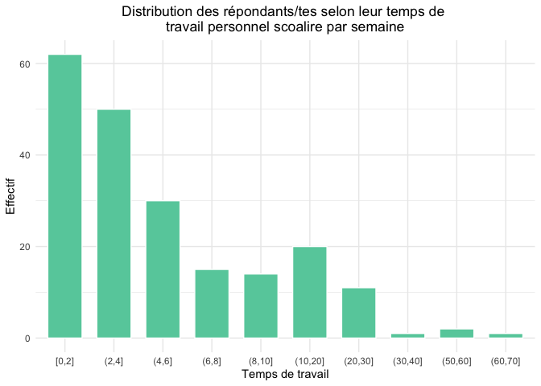

Comme le montre le graphique ci-dessus, la plupart des étudiants travaillent entre 0 et 6 heures par semaine pour leurs études. Ensuite plus le temps de travail par semaine est élevé, moins les effectifs sont élevés. On peut noter que très peu d’élèves ont un temps de travail personnel scolaire supérieur à 30 heures par semaine.

### 2. Impact du nombre de soirées sur le temps de travail

Dans cette partie, nous allons étudier comment le temps de travail des étudiants est impacté par le nombre de soirées par semaine réalisées.

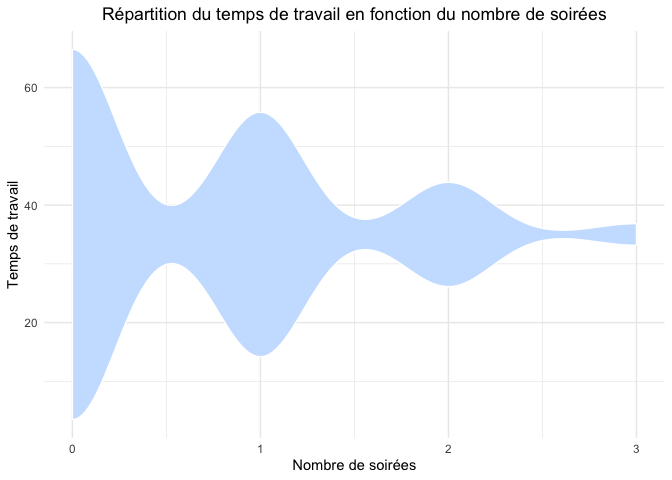

Nous pouvons constater que plus le nombre de soirées augmente, plus le temps de travail diminue.

### 3. Nombre de soirées et temps de travail selon le genre, l’année d’étude

A présent, nous allons analyser les données afin de déterminer si le nombre de soirées impacte différemment le temps de travail des étudiants selon leur :

- Année d’étude
- Genre

Afin de mieux représenter le temps de travail des étudiants en fonction du nombre de soirées, nous avons créé deux fonction qui permettent de calculer la moyenne de leur temps de travail en fonction du nombre de soirées qu’ils réalisent par semaine selon l’année d’étude et le genre de l’individu.

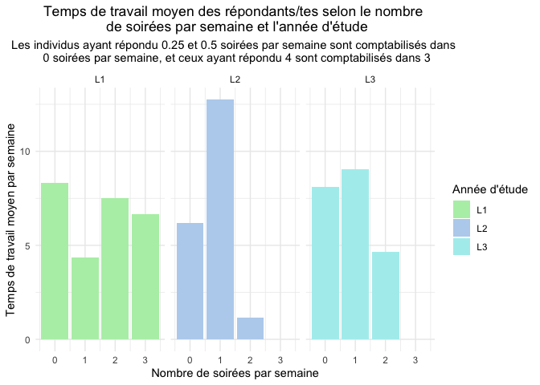

On remarque également que les L1 font plus de soirées par semaine, que les L2 et L3 qui eux sont répartis sur aucune, une ou deux soirées par semaine. On remarque donc qu’être en L1 ou en L2, L3 n’a pas le même impact sur le nombre de soirées par semaine et donc sur le temps de travail de l’individu.

Cependant, pour les individus ne réalisant aucune soirée par semaine on peut noter que les L1 et les L3 ont quasiment le même temps de travail moyen, on ne fait donc pas de différence selon l’année d’étude ici.

Mais si l’on regarde un nombre de soirées positif, on observe bien un lien entre l’année d’étude et l’impact du nombre de soirées sur le temps de travail : les L1 réalisant une soirée par semaine travaillent moins que les L3 pour un même nombre de soirées.

On observe aussi une différence de temps de travail pour les étudiants réalisant deux soirées par semaine : les L1 travaillent plus que les L2 et L3.

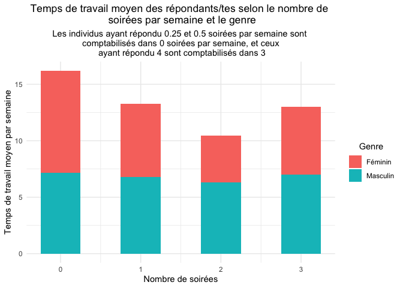

On remarque également la même relation négative entre le nombre de soirées et le temps de travail moyen de l’étudiant ici.

En analysant selon le genre on observe que pour les répondants ne faisant pas de soirées, les filles travaillent plus que les garçons.

Mais lorsqu’on s’intéresse aux étudiants faisant une soirée par semaine ou plus, on observe avec le graphique précédent que les garçons gardent un temps de travail moyen par semaine quasiment similaire qu’ils fassent une, deux ou trois soirées par semaine.

Donc selon le genre, le nombre de soirées par semaine n’a pas le même impact sur le temps de travail.

### 4. Analyse de possibles corrélations

Une étude des corrélations entre le temps de travail par semaine et l’année d’étude, le genre des étudiants va être réalisée dans cette partie. Pour cela nous allons créer une fonction qui va nous permettre d’effectuer plus facilement les tests du χ2. Une fonction afin de résumer les résultats des différents tests va également être créée.

Tableau représentant les p-value des tests du χ2

|  | p-value |
| --- | --- |
| Test temps de travail et soirées | 0.950 |
| Test temps travail et année d’étude | 0.004 |
| Test temps de travail et genre | 0.430 |
| Test soirées et année d’étude | 0.210 |
| Test soirées et genre | 0.350 |

Soit un seuil de significativité de **5%**. En observant les résultats des tests du χ2 résumés dans le tableau ci-dessus, on peut dire que le temps de travail dépend seulement de l’année d’étude.

En effet, avec ce type de test, l’hypothèse nulle indique que les deux variables sont indépendantes. Cette hypothèse est rejetée lorsque la p-value du test est inférieure au seuil de significativité, soit ici **5%**. En regardant les résultats des autres tests, on a des p-values supérieures à **5%**.

Donc d’après les résultats de ces tests, le temps de travail est indépendant du nombre de soirées et du genre, et le nombre de soirées par semaine est indépendant du genre et de l’année d’étude de l’individu. Jusqu’ici ce n’est pas vraiment ce que l’on a pu observer avec les différents graphiques réalisés. Mais on peut penser que les résultats de ces tests, non représentatifs, de notre étude viennent de nos données et de la taille de notre échantillon. On peut donc laisser un doute sur la précision de ces résultats.

### 5. Rythme de consommation d’alcool et nombre de soirées

En observant les données de notre sondage, on remarque la variable Rythme de consommation d’alcool. Il nous semblait pertinent d’étudier le lien éventuel entre le rythme de consommation d’alcool et le nombre de soirées par semaine. Nous allons pour cela réaliser un graphique, un tableau et un test du χ2.

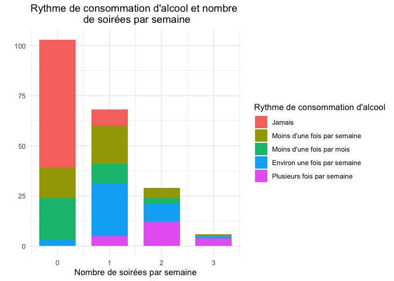

En observant le graphique ci-dessus, on observe qu’une grande part des étudiants n’allant jamais en soirée ne boivent jamais d’alcool.

De plus en regardant les nombres de soirées plus élevés, on remarque que la plupart des étudiants réalisant plus d’une soirée sont ceux qui boivent le plus d’alcool, soit ceux qui consomment de l’alcool environ une fois par semaine et plusieurs fois par semaine.

A première vue, on peut s’attendre à une relation positive entre le rythme de consommation d’alcool et le nombre de soirées.

Répondants/tes selon le rythme de consommation d’alcool et le nombre de soirées par semaine

|  | 0 | 1 | 2 | 3 |
| --- | --- | --- | --- | --- |
| Jamais | 64 | 8 | 0 | 0 |
| Moins d’une fois par semaine | 15 | 19 | 5 | 1 |
| Moins d’une fois par mois | 21 | 10 | 3 | 0 |
| Environ une fois par semaine | 3 | 26 | 9 | 1 |
| Plusieurs fois par semaine | 0 | 5 | 12 | 4 |

En observant le tableau ci-dessus on peut déceler des observations plus précises notamment avec des valeurs en pourcentages. Afin de calculer certaines valeurs en pourcentages, nous avons créé une fonction qui permet de sélectionner certaines cases de notre tableau. Ensuite nous les avons exposées en pourcentages.

On observe donc la même hypothèse qu’avec le graphique. Nous allons réaliser un test de χ2 pour valider ou non cette hypothèse.